# CBE R Workshop

Max & Evelyn

### Intro to R and RMarkdown

This is what a code chunk is:

```r
print("hello world! :)")
```

```
## [1] "hello world! :)"
```

The code within the chunk, which is demarcated by three tick symbols (`), will be executed. You can add tinker with different options in the **chunk header**, which is enclosed by the two brackets ({}). One useful chunk option is *echo = FALSE*, which suppresses the code from showing and only produces an output.

For example, if we add *echo = FALSE* to the above code chunk, we only get the printed output.

```
## [1] "hello world! :)"
```

You can “knit” an RMarkdown by clicking the yarn icon, or by using the keyboard shortcut (there are a lot of these in RStudio): CTRL/CMD + SHIFT + K. This creates a prettier HTML output.

You can save a document by going to File-> Save or with the shortcut CTRL/CMD + S.

```r
print("Hello world")
```

```
## [1] "Hello world"
```

```r
# The above is a line of code. This is a comment.
```

You can create comments, or sections of text that will not be executed as code, by adding a ‘#’ in front of the section.

### Loading packages

Different packages in R do different things. There’s a package that helps you plot pretty things called **ggplot**, a package that contains a bunch of useful functions for data transformation and analysis called **dplyr**, and even a fortune teller package. There’s even a package that contains the first two packages. We’ll be installing this one.

```r
#install.packages("tidyverse")
```

Once you’ve installed it, you need to *load* the package before use. Every time you restart R, it forgets about your previous session. You can load packages like so:

```r
library(tidyverse)
```

### Exploratory data analysis

We will be working with a publicly available dataset from Our World in Data called “Coronavirus (COVID-19) Vaccinations”.

Once you have it downloaded, make sure it is in the same folder as the RMarkdown document you have with code. You can read in a CSV file using a function called read.csv(“FILENAME.csv”)

```r
vaccine_data <- read_csv("vaccine_data.csv")
```

We can use the summary function to immediately display a number of summary statistics.

```r
summary(vaccine_data)
```

```
##       date              location         total_vaccinations total_distributed
##  Min.   :2020-12-20   Length:2688        Min.   :     416   Min.   :    6000
##  1st Qu.:2021-01-21   Class :character   1st Qu.:  109027   1st Qu.:  182025
##  Median :2021-02-01   Mode  :character   Median :  315450   Median :  533800
##  Mean   :2021-01-31                      Mean   : 1136793   Mean   : 1680657
##  3rd Qu.:2021-02-11                      3rd Qu.:  751906   3rd Qu.: 1101712
##  Max.   :2021-02-21                      Max.   :63090634   Max.   :78152495
##                                          NA's   :270        NA's   :317
##  people_vaccinated  people_fully_vaccinated_per_hundred
##  Min.   :     401   Min.   : 0.000
##  1st Qu.:   84310   1st Qu.: 0.970
##  Median :  243620   Median : 2.040
##  Mean   :  832219   Mean   : 2.572
##  3rd Qu.:  552126   3rd Qu.: 3.720
##  Max.   :43628092   Max.   :14.880
##  NA's   :329        NA's   :552
##  total_vaccinations_per_hundred people_fully_vaccinated
##  Min.   : 0.17                  Min.   :       1
##  1st Qu.: 6.22                  1st Qu.:   19804
##  Median : 9.98                  Median :   59903
##  Mean   :10.71                  Mean   :  247642
##  3rd Qu.:14.54                  3rd Qu.:  154639
##  Max.   :35.26                  Max.   :18865319
##  NA's   :450                    NA's   :411
##  people_vaccinated_per_hundred distributed_per_hundred daily_vaccinations_raw
##  Min.   : 0.240                Min.   : 6.14           Min.   :  -1027
##  1st Qu.: 5.360                1st Qu.:12.29           1st Qu.:   3124
##  Median : 7.970                Median :16.35           Median :  12379
##  Mean   : 8.186                Mean   :17.71           Mean   :  47601
##  3rd Qu.:10.640                3rd Qu.:20.66           3rd Qu.:  31144
##  Max.   :20.830                Max.   :52.88           Max.   :2242472
##  NA's   :475                   NA's   :463             NA's   :65
##  daily_vaccinations daily_vaccinations_per_million share_doses_used
##  Min.   :      0    Min.   :    0                  Min.   :0.0430
##  1st Qu.:   4204    1st Qu.: 2895                  1st Qu.:0.4860
##  Median :  13479    Median : 3781                  Median :0.6070
##  Mean   :  44453    Mean   : 4014                  Mean   :0.6010
##  3rd Qu.:  29397    3rd Qu.: 4706                  3rd Qu.:0.7275
##  Max.   :1716311    Max.   :17886                  Max.   :1.0890
##  NA's   :65         NA's   :260                    NA's   :317
```

Let’s say we want to take a peek at our spreadsheet, but we we’re not feeling numbers today. We can use the view function to see the data right in RStudio.

```r
View(vaccine_data)
```

Glimpse is alternative way to view part of the data in R (note that this requires the TidyVerse library to be loaded).

```r
glimpse(vaccine_data)
```

```
## Rows: 2,688
## Columns: 14
## $ date                                <date> 2021-01-12, 2021-01-13, 2021-0...
## $ location                            <chr> "Alabama", "Alabama", "Alabama"...
## $ total_vaccinations                  <dbl> 78134, 84040, 92300, 100567, NA...
## $ total_distributed                   <dbl> 377025, 378975, 435350, 444650,...
## $ people_vaccinated                   <dbl> 70861, 74792, 80480, 86956, NA,...
## $ people_fully_vaccinated_per_hundred <dbl> 0.15, 0.19, NA, 0.27, NA, NA, N...
## $ total_vaccinations_per_hundred      <dbl> 1.59, 1.71, 1.88, 2.05, NA, NA,...
## $ people_fully_vaccinated             <dbl> 7270, 9245, NA, 13488, NA, NA, ...
## $ people_vaccinated_per_hundred       <dbl> 1.44, 1.52, 1.64, 1.77, NA, NA,...
## $ distributed_per_hundred             <dbl> 7.69, 7.73, 8.88, 9.07, NA, NA,...
## $ daily_vaccinations_raw              <dbl> NA, 5906, 8260, 8267, 7557, 755...
## $ daily_vaccinations                  <dbl> NA, 5906, 7083, 7478, 7498, 750...
## $ daily_vaccinations_per_million      <dbl> NA, 1205, 1445, 1525, 1529, 153...
## $ share_doses_used                    <dbl> 0.207, 0.222, 0.212, 0.226, NA,...
```

You might notice symbols like and in the above output. These are known as variable types in R. If you have learned another programming language, you might remember that you cannot add a number to a word (oftentimes this will result in *undefined behavior*), and the same is true in R. In the case of the above output stands for character, which is functionally the same as a word. You can recognize a character data type because characters are always surrounded by quotation marks. Doubles, or numerics as they are known in R, are essentially numbers. In some programming languages, integers (whole numbers), and doubles (decimal numbers) are considered as different datatypes — there is no such distinction in R.

You might notice that some values that were printed out above said “NA” instead of a number (or a character). This often means that despite there being other values associated with a particular data entry, there was no particular value recorded for that specific part of the data entry. It would be wasteful to remove the rest of the data associated with the entry (as it could be useful for other applications), but at the same time NA values can make certain calculations difficult. For example, if we were to sum all of the daily vaccinations without any manipulation of the data, the end result is an NA value, which is completely useless.

```r
sum(vaccine_data$daily_vaccinations)
```

```
## [1] NA
```

One of the simplest ways to deal with NA values is to use the `na.omit` command, which omits any NA values from a dataset. This resolves the issue we saw above.

```r
sum(na.omit(vaccine_data$daily_vaccinations))
```

```
## [1] 116600833
```

You can think of variables and columns as synonymous in a data table.

### Data transformation with dplyr

Now that we’ve checked our data for any loose ends, like NA values, let’s get to manipulating the data. The **dplyr** package contains various functions that help you transform variables.

Here is a quick list of what the most common functions do: * `filter()` - subsets your data by certain values * `select()` - selects or deselects certain variables * `arrange()` - sorts your data in descending or ascending value * `summarize()` - calculates an output that is a single value * `mutate()` - creates new columns

Let’s say we’re only interested in viewing the observations from February 21, 2021.

```r
vaccine_data %>%
  filter(date == "2021-02-21")
```

```
## # A tibble: 65 x 14
##    date       location total_vaccinati~ total_distribut~ people_vaccinat~
##    <date>     <chr>               <dbl>            <dbl>            <dbl>
##  1 2021-02-21 Alabama            788613          1082100           567505
##  2 2021-02-21 Alaska             235141           299935           152349
##  3 2021-02-21 America~            18778            29450            10948
##  4 2021-02-21 Arizona           1469676          1688255          1087921
##  5 2021-02-21 Arkansas           528467           691525           367436
##  6 2021-02-21 Bureau ~            52266            49175            32591
##  7 2021-02-21 Califor~          7453468          9178020          5426591
##  8 2021-02-21 Colorado          1202161          1348800           817009
##  9 2021-02-21 Connect~           860534           984275           579380
## 10 2021-02-21 Delaware           180940           204200           133251
## # ... with 55 more rows, and 9 more variables:
## #   people_fully_vaccinated_per_hundred <dbl>,
## #   total_vaccinations_per_hundred <dbl>, people_fully_vaccinated <dbl>,
## #   people_vaccinated_per_hundred <dbl>, distributed_per_hundred <dbl>,
## #   daily_vaccinations_raw <dbl>, daily_vaccinations <dbl>,
## #   daily_vaccinations_per_million <dbl>, share_doses_used <dbl>
```

Now you can see there are only 65 observations that match this condition.

We only want the variable `people_fully_vaccinated`.

```r
vaccine_data %>%
  select(people_fully_vaccinated)
```

```
## # A tibble: 2,688 x 1
##    people_fully_vaccinated
##                      <dbl>
##  1                    7270
##  2                    9245
##  3                      NA
##  4                   13488
##  5                      NA
##  6                      NA
##  7                      NA
##  8                   16346
##  9                   17956
## 10                   21345
## # ... with 2,678 more rows
```

What if we want all variables *besides* `people_fully_vaccinated`?

```r
vaccine_data %>%
  select(-people_fully_vaccinated)
```

```
## # A tibble: 2,688 x 13
##    date       location total_vaccinati~ total_distribut~ people_vaccinat~
##    <date>     <chr>               <dbl>            <dbl>            <dbl>
##  1 2021-01-12 Alabama             78134           377025            70861
##  2 2021-01-13 Alabama             84040           378975            74792
##  3 2021-01-14 Alabama             92300           435350            80480
##  4 2021-01-15 Alabama            100567           444650            86956
##  5 2021-01-16 Alabama                NA               NA               NA
##  6 2021-01-17 Alabama                NA               NA               NA
##  7 2021-01-18 Alabama                NA               NA               NA
##  8 2021-01-19 Alabama            130795           444650           114319
##  9 2021-01-20 Alabama            139200           483275           121113
## 10 2021-01-21 Alabama            165919           493125           144429
## # ... with 2,678 more rows, and 8 more variables:
## #   people_fully_vaccinated_per_hundred <dbl>,
## #   total_vaccinations_per_hundred <dbl>, people_vaccinated_per_hundred <dbl>,
## #   distributed_per_hundred <dbl>, daily_vaccinations_raw <dbl>,
## #   daily_vaccinations <dbl>, daily_vaccinations_per_million <dbl>,
## #   share_doses_used <dbl>
```

Now let’s see which state has the highest number of `people_fully_vaccinated` as of February 21, 2021.

```r
vaccine_data %>%
  filter(date == "2021-02-21") %>%
  arrange(desc(people_fully_vaccinated))
```

```
## # A tibble: 65 x 14
##    date       location total_vaccinati~ total_distribut~ people_vaccinat~
##    <date>     <chr>               <dbl>            <dbl>            <dbl>
##  1 2021-02-21 United ~         63090634         75204965         43628092
##  2 2021-02-21 Califor~          7453468          9178020          5426591
##  3 2021-02-21 Florida           4387051          5120975          2877011
##  4 2021-02-21 Texas             4673868          5652800          3267255
##  5 2021-02-21 New Yor~          3621973          4171175          2369520
##  6 2021-02-21 North C~          2068505          2363200          1373952
##  7 2021-02-21 Ohio              2140688          2518775          1486509
##  8 2021-02-21 Michigan          1933648          2279240          1267083
##  9 2021-02-21 Pennsyl~          2306828          2989725          1667727
## 10 2021-02-21 Georgia           1850856          2292085          1202374
## # ... with 55 more rows, and 9 more variables:
## #   people_fully_vaccinated_per_hundred <dbl>,
## #   total_vaccinations_per_hundred <dbl>, people_fully_vaccinated <dbl>,
## #   people_vaccinated_per_hundred <dbl>, distributed_per_hundred <dbl>,
## #   daily_vaccinations_raw <dbl>, daily_vaccinations <dbl>,
## #   daily_vaccinations_per_million <dbl>, share_doses_used <dbl>
```

`summarize()` is a useful function for basic statistics, like `mean()`, `median()`, or `sum()`.

```r
vaccine_data %>%
  filter(date == "2021-02-21",
         location != "United States",
         !is.na(people_fully_vaccinated)) %>%
  summarize(mean(people_fully_vaccinated))
```

```
## # A tibble: 1 x 1
##   `mean(people_fully_vaccinated)`
##                             <dbl>
## 1                         313989.
```

However, `mutate()` is useful for calculating a unique value per observation. Let’s say we want to find the rate of vaccinations and distributions:

```r
vaccine_data %>%
  filter(!is.na(people_vaccinated),
         !is.na(total_distributed)) %>%
  mutate(newvariable = people_vaccinated / total_distributed)
```

```
## # A tibble: 2,359 x 15
##    date       location total_vaccinati~ total_distribut~ people_vaccinat~
##    <date>     <chr>               <dbl>            <dbl>            <dbl>
##  1 2021-01-12 Alabama             78134           377025            70861
##  2 2021-01-13 Alabama             84040           378975            74792
##  3 2021-01-14 Alabama             92300           435350            80480
##  4 2021-01-15 Alabama            100567           444650            86956
##  5 2021-01-19 Alabama            130795           444650           114319
##  6 2021-01-20 Alabama            139200           483275           121113
##  7 2021-01-21 Alabama            165919           493125           144429
##  8 2021-01-22 Alabama            199314           519525           174317
##  9 2021-01-23 Alabama            221540           521225           193955
## 10 2021-01-24 Alabama            243737           521225           213833
## # ... with 2,349 more rows, and 10 more variables:
## #   people_fully_vaccinated_per_hundred <dbl>,
## #   total_vaccinations_per_hundred <dbl>, people_fully_vaccinated <dbl>,
## #   people_vaccinated_per_hundred <dbl>, distributed_per_hundred <dbl>,
## #   daily_vaccinations_raw <dbl>, daily_vaccinations <dbl>,
## #   daily_vaccinations_per_million <dbl>, share_doses_used <dbl>,
## #   newvariable <dbl>
```

There’s so much more you can do with **dplyr**. Another useful function is *group_by()*, which creates groups based on a certain variable. For example, finding the mean number of people fully vaccinated isn’t very helpful when your data contains observations from New York in December 2020 and Oregon in February 2021.

*group_by()* essentially sidesteps this problem of comparison by calculating statistics within a given group.

```r
vaccine_data %>%
  select(date, people_fully_vaccinated, location) %>%
  filter(!is.na(people_fully_vaccinated),
         location != "United States") %>%
  group_by(date) %>%
  summarize(mean(people_fully_vaccinated))
```

```
## # A tibble: 36 x 2
##    date       `mean(people_fully_vaccinated)`
##    <date>                               <dbl>
##  1 2021-01-12                          14531.
##  2 2021-01-13                          18857.
##  3 2021-01-15                          25976.
##  4 2021-01-19                          32631.
##  5 2021-01-20                          34862.
##  6 2021-01-21                          38628.
##  7 2021-01-22                          44467.
##  8 2021-01-23                          48837.
##  9 2021-01-24                          51884.
## 10 2021-01-25                          53974.
## # ... with 26 more rows
```

```r
# Always gut check your results!
```

### Plotting with ggplot

When you have a good grasp of your findings, you might want to visualize those results. The **ggplot2* package has a robust collection of functions and themes to do this in the PRETTIEST manner possible.

We won’t go over examples of each, but here’s a cheat sheet of what each function does: * `geom_bar()` creates a bar plot, which is good for graphing categorical variables. * `geom_hist()` creates a histogram. * `geom_point()` creates a scatter plot, good for continuous (or numerical) variables. * `geom_boxplot()` creates a boxplot, good for looking at central tendency and distribution. * `geom_line()` creates a line graph, good for continuous variables.

Let’s say we want to see how vaccinations per capita have progressed over time in the state of Massachusetts.

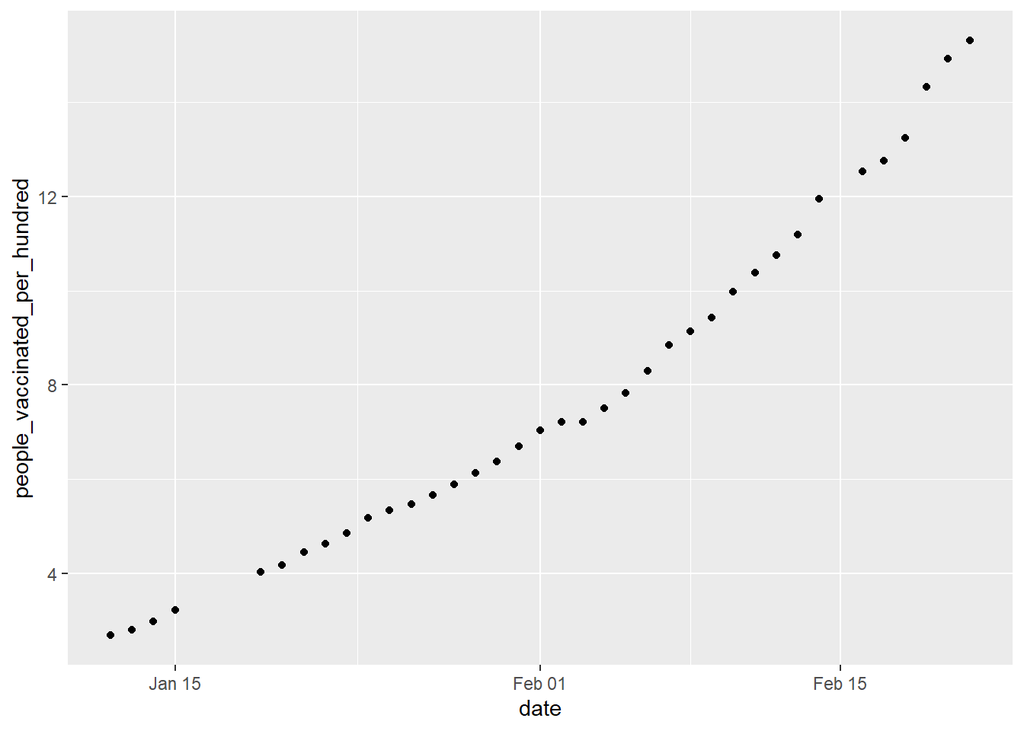

```r
# First, we need to start with ggplot().
ggplot(data = massonly) +
  # Note how we're using plus signs instead of the %>% operator! This is only
  # for when using the ggplot2 package.
  geom_point(mapping = aes(x = date, y = people_vaccinated_per_hundred))
```

You can replace `geom_point()` with `geom_line()`. It’s that easy to create plots using **ggplot2**.

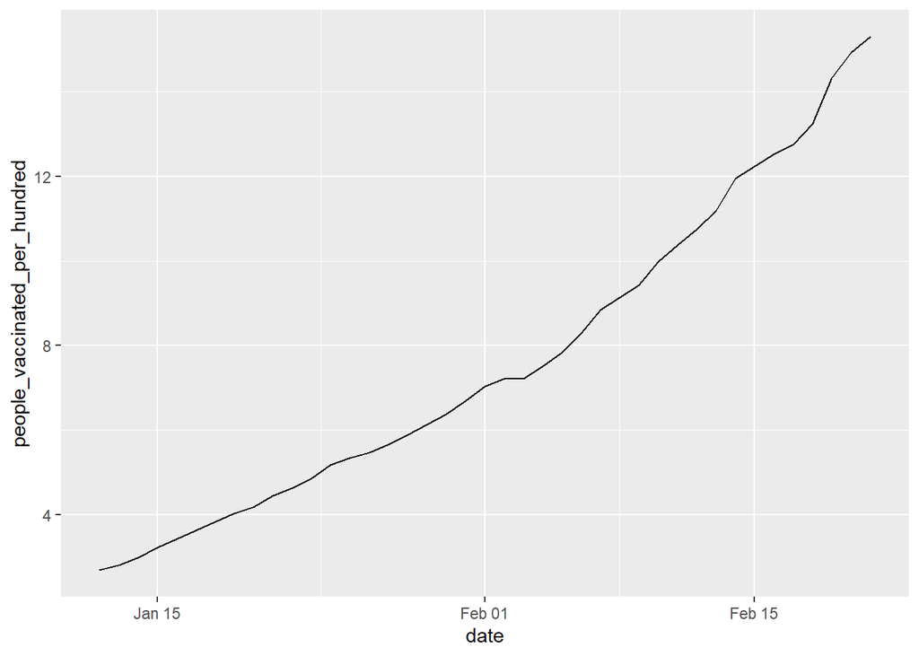

```r
# Run it back
ggplot(data = massonly) +
  geom_line(mapping = aes(x = date, y = people_vaccinated_per_hundred))
```

Now that this is looking more sensible, we can add labels using the `labs()` function. You can use `xlab()` and `ylab()` to change the axis titles.

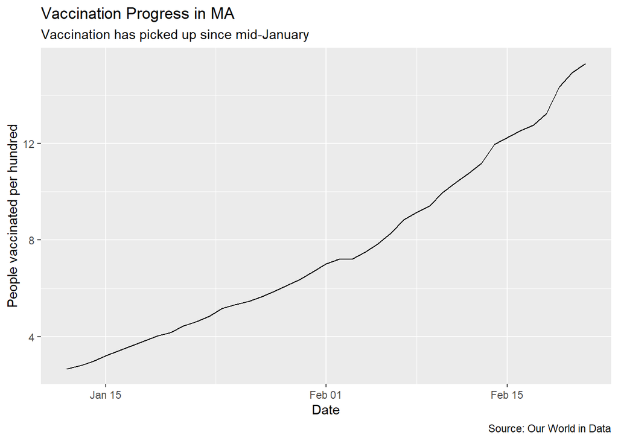

```r
# Make it make sense
ggplot(data = massonly) +
  geom_line(mapping = aes(x = date, y = people_vaccinated_per_hundred)) +
  labs(title = "Vaccination Progress in MA",
       subtitle = "Vaccination has picked up since mid-January",
       caption = "Source: Our World in Data") +
  xlab("Date") +
  ylab("People vaccinated per hundred")
```

You can even make it look pretty with a variety of themes.

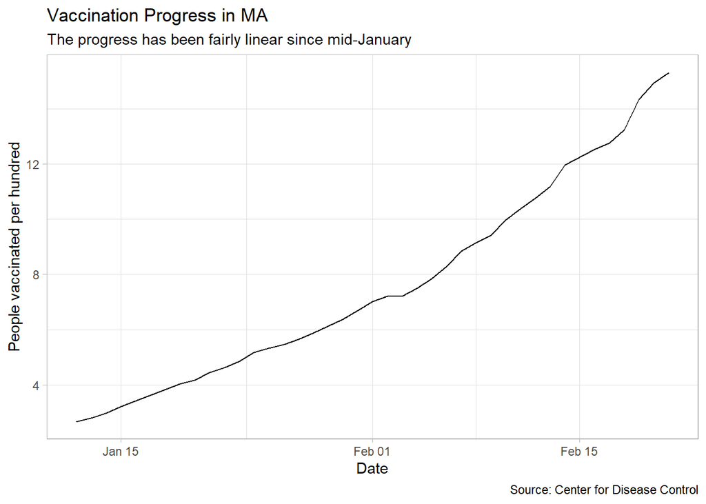

```r
ggplot(data = massonly) +
  geom_line(mapping = aes(x = date, y = people_vaccinated_per_hundred)) +
  labs(title = "Vaccination Progress in MA",
       subtitle = "The progress has been fairly linear since mid-January",
       caption = "Source: Center for Disease Control") +
  xlab("Date") +
  ylab("People vaccinated per hundred") +
  # Simply add a theme.
  theme_light()
```

We won’t go too in depth, but the world is your oyster when it comes to visualizing with R. Below is a neat graph that Max and I created using this dataset. Can you replicate it?

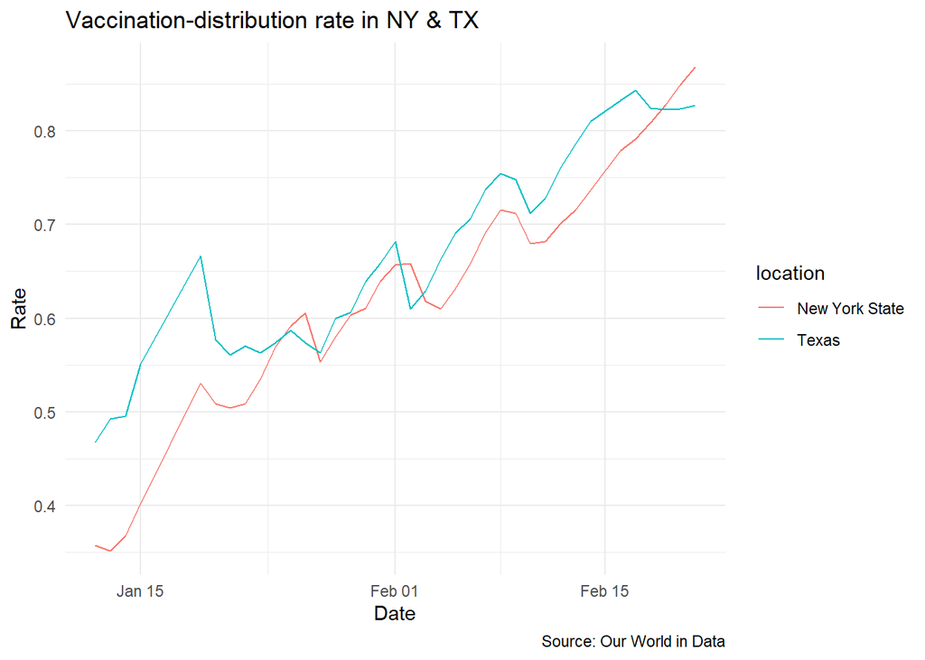

### Other R applications

You can do so much more with R, including but not limited to mapping / GIS stuff!!! And making a website! And election predictions, and [COVID dashboards](https://blog.rstudio.com/2020/11/19/using-shiny-in-production-to-monitor-covid-19/), and machine learning.

If you want to learn more, I highly recommend the [R primers](https://rstudio.cloud/learn/primers) created by RStudio.